# Caballero Osorio, Fabian - Quiz 4 (Week 9) Feedback

| Course | Assessment |
| --- | --- |
| Machine Learning | Quiz 4 (Week 9) |

| Student Name | Student ID |
| --- | --- |
| Caballero Osorio, Fabian | S3912233 |

### General Assessment Feedback

This assessment covered model evaluation as well as feature selection and ranking. Overall, it was handled well by majority of the students with the class average being about 23/30.

### Student Assessment Results & Feedback

Question

Student Answer

Correct Answer

Feedback

Score

Student Name & ID  
(link)  
(0 points)

Name: Fabian Caballero Osorio  
Student ID: s3912233

(Student Name & ID)

*************************  
**STUDENT FEEDBACK:**  
*************************  
**(Student Name & ID)**

0.0

Question 1  
(link)  
(2 points)

```
### ADD YOUR CODE BELOW

tp = 32
fn = 8
tn = 28
fp = 2

accuracy = (tp+tn)/(tp+tn+fp+fn)

### ADD YOUR CODE ABOVE

print(f"accuracy is {accuracy:.2f}")

OUTPUT:
accuracy is 0.86
```

```
### ADD YOUR CODE BELOW

accuracy = (28+32) / (30+40)

# accuracy = 999

### ADD YOUR CODE ABOVE

print(f"accuracy is {accuracy:.2f}")

OUTPUT:
accuracy is 0.86
```

*************************  
**STUDENT FEEDBACK:**  
*************************  
**Full credit was awarded for this answer.**  
*************************  
**GENERAL FEEDBACK:**  
*************************  
Please refer to the correct solutions.

2.0

Question 2  
(link)  
(2 points)

```
### ADD YOUR CODE BELOW

tp = 32
fn = 8
tn = 28
fp = 2

recall = tp/(tp+fn)

### ADD YOUR CODE ABOVE

print(f"recall is {recall:.2f}")

OUTPUT:
recall is 0.80
```

```
### ADD YOUR CODE BELOW

recall = 32/40

# recall = 999

### ADD YOUR CODE ABOVE

print(f"recall is {recall:.2f}")

OUTPUT:
recall is 0.80
```

*************************  
**STUDENT FEEDBACK:**  
*************************  
**Full credit was awarded for this answer.**  
*************************  
**GENERAL FEEDBACK:**  
*************************  
Please refer to the correct solutions.

2.0

Question 3  
(link)  
(2 points)

```
### ADD YOUR CODE BELOW

tp = 32
fn = 8
tn = 28
fp = 2

tnr = tn/(tn+fp)

### ADD YOUR CODE ABOVE

print(f"true negative rate is {tnr:.2f}")

OUTPUT:
true negative rate is 0.93
```

```
### ADD YOUR CODE BELOW

tnr = 28/30

# tnr = 999

### ADD YOUR CODE ABOVE

print(f"true negative rate is {tnr:.2f}")

OUTPUT:
true negative rate is 0.93
```

*************************  
**STUDENT FEEDBACK:**  
*************************  
**Full credit was awarded for this answer.**  
*************************  
**GENERAL FEEDBACK:**  
*************************  
Please refer to the correct solutions.

2.0

Question 4  
(link)  
(2 points)

```
### ADD YOUR CODE BELOW

tp = 32
fn = 8
tn = 28
fp = 2

precision = tp/(tp+fp)

### ADD YOUR CODE ABOVE

print(f"precision is {precision:.2f}")

OUTPUT:
precision is 0.94
```

```
### ADD YOUR CODE BELOW

precision = 32/34

# precision = 999

### ADD YOUR CODE ABOVE

print(f"precision is {precision:.2f}")

OUTPUT:
precision is 0.94
```

*************************  
**STUDENT FEEDBACK:**  
*************************  
**Full credit was awarded for this answer.**  
*************************  
**GENERAL FEEDBACK:**  
*************************  
Please refer to the correct solutions.

2.0

Question 5  
(link)  
(2 points)

```
### ADD YOUR CODE BELOW
tp = 32
fn = 8
tn = 28
fp = 2

precision = tp/(tp+fp)
recall = tp/(tp+fn)

f_1 = 2*(precision*recall)/(precision+recall)

aca_harmonic = f_1

### ADD YOUR CODE ABOVE

print(f"the harmonic average class accuracy is {aca_harmonic:.2f}")

OUTPUT:
the harmonic average class accuracy is 0.86
```

```
### ADD YOUR CODE BELOW

recall_positive = 32/40
recall_negative = 28/30

aca_harmonic =  1 / ((1/2) * ((1/recall_positive) + (1/recall_negative)))

# aca_harmonic = 999
### ADD YOUR CODE ABOVE

print(f"the harmonic average class accuracy is {aca_harmonic:.2f}")

OUTPUT:
the harmonic average class accuracy is 0.86
```

*************************  
**STUDENT FEEDBACK:**  
*************************  
**Full credit was awarded for this answer.**  
*************************  
**GENERAL FEEDBACK:**  
*************************  
Please refer to the correct solutions.

2.0

Question 6  
(link)  
(2 points)

```
import numpy as np

auc_knn = np.array([0.89, 0.87, 0.87, 0.88, 0.90, 0.89, 0.87, 0.89, 0.88, 0.85])
auc_dt = np.array([0.87, 0.85, 0.85, 0.86, 0.88, 0.87, 0.85, 0.87, 0.86, 0.89])


### ADD YOUR CODE BELOW


auc_knn_mean = auc_knn.mean().round(3)
auc_dt_mean = auc_dt.mean().round(3)

### ADD YOUR CODE ABOVE

print(f"average AUC for KNN is {auc_knn_mean:.2f} and average AUC for DT is {auc_dt_mean:.2f}")

OUTPUT:
average AUC for KNN is 0.88 and average AUC for DT is 0.86
```

```
import numpy as np

auc_knn = np.array([0.89, 0.87, 0.87, 0.88, 0.90, 0.89, 0.87, 0.89, 0.88, 0.85])
auc_dt = np.array([0.87, 0.85, 0.85, 0.86, 0.88, 0.87, 0.85, 0.87, 0.86, 0.89])


### ADD YOUR CODE BELOW

auc_knn_mean = auc_knn.mean()
auc_dt_mean = auc_dt.mean()

# auc_knn_mean = 999
# auc_dt_mean = 999

### ADD YOUR CODE ABOVE

print(f"average AUC for KNN is {auc_knn_mean:.2f} and average AUC for DT is {auc_dt_mean:.2f}")

OUTPUT:
average AUC for KNN is 0.88 and average AUC for DT is 0.86
```

*************************  
**STUDENT FEEDBACK:**  
*************************  
**Full credit was awarded for this answer.**  
*************************  
**GENERAL FEEDBACK:**  
*************************  
Please refer to the correct solutions.

2.0

Question 7  
(link)  
(2 points)

```
from scipy import stats
import numpy as np

auc_knn = np.array([0.89, 0.87, 0.87, 0.88, 0.90, 0.89, 0.87, 0.89, 0.88, 0.85])
auc_dt = np.array([0.87, 0.85, 0.85, 0.86, 0.88, 0.87, 0.85, 0.87, 0.86, 0.89])


### ADD YOUR CODE BELOW


p_value = stats.ttest_rel(auc_dt,auc_knn).pvalue.round(3)

### ADD YOUR CODE ABOVE

print(f"the p value is {p_value:.2f}")

OUTPUT:
the p value is 0.04
```

```
from scipy import stats
import numpy as np

auc_knn = np.array([0.89, 0.87, 0.87, 0.88, 0.90, 0.89, 0.87, 0.89, 0.88, 0.85])
auc_dt = np.array([0.87, 0.85, 0.85, 0.86, 0.88, 0.87, 0.85, 0.87, 0.86, 0.89])


### ADD YOUR CODE BELOW

p_value = stats.ttest_rel(auc_knn, auc_dt).pvalue

# p_value = 999

### ADD YOUR CODE ABOVE

print(f"the p value is {p_value:.2f}")

OUTPUT:
the p value is 0.04
```

*************************  
**STUDENT FEEDBACK:**  
*************************  
**Full credit was awarded for this answer.**  
*************************  
**GENERAL FEEDBACK:**  
*************************  
Please refer to the correct solutions.

2.0

Question 8  
(link)  
(2 points)

The KNN model is statistically better than the DT model

The KNN model is statistically better than the DT model

*************************  
**STUDENT FEEDBACK:**  
*************************  
**Full credit was awarded for this answer.**  
*************************  
**GENERAL FEEDBACK:**  
*************************  
Please refer to the correct solutions.

2.0

Question 9  
(link)  
(5 points)

```
import numpy as np
import pandas as pd
from sklearn import feature_selection as fs

df = pd.read_csv("iris.csv")

# task 1: read in the number of features to select as a user input
S = int(float(input('Waiting for input: ')))

# task 2: define the target feature
target = df['species'].values

# task 3: define the set of descriptive features in two different ways:
# 1- as a Pandas data frame (so that we can recover the feature names after feature selection)
# 2- as a Numpy array (to use within scikit-learn functions)
Data_df = df.drop(columns = 'species')
Data_numpy = df.drop(columns = 'species').values


# task 4: select the best S features with the F-score method
# using the entire dataset

### ADD YOUR CODE BELOW

fs_fit_fscore = fs.SelectKBest(fs.f_classif, k=S)
fs_fit_fscore.fit_transform(X=Data_numpy,y=Data_df)
fs_indices_fscore = np.argsort(np.nan_to_num(fs_fit_fscore.scores_))[::-1][0:num_features]

### ADD YOUR CODE ABOVE


# task 5: let's see what these best features are as selected by the f-score method

### ADD YOUR CODE BELOW

best_features_fscore = np.argsort(np.nan_to_num(fs_fit_fscore.scores_))[::-1][0:num_features]

### ADD YOUR CODE ABOVE

# print the best features as a Python list as this looks nicer compared to printing a numpy array
print(list(best_features_fscore))

UNIT TEST RESULTS:
Test 1: Failed. (Test did not execute successfully)
```

```
import numpy as np
import pandas as pd
from sklearn import feature_selection as fs

df = pd.read_csv("iris.csv")

# task 1: read in the number of features to select as a user input
S = int(float(input('Waiting for input: ')))

# task 2: define the target feature
target = df['species'].values

# task 3: define the set of descriptive features in two different ways:
# 1- as a Pandas data frame (so that we can recover the feature names after feature selection)
# 2- as a Numpy array (to use within scikit-learn functions)
Data_df = df.drop(columns = 'species')
Data_numpy = df.drop(columns = 'species').values

# task 4: select the best S features with the F-score method
# using the entire dataset

### ADD YOUR CODE BELOW

fs_fit_fscore = fs.SelectKBest(fs.f_classif, k=S)
fs_fit_fscore.fit_transform(Data_numpy, target)
fs_indices_fscore = np.argsort(np.nan_to_num(fs_fit_fscore.scores_))[::-1][0:S]

# fs_indices_fscore = 999

### ADD YOUR CODE ABOVE

# task 5: let's see what these best features are as selected by the f-score method
best_features_fscore = Data_df.columns[fs_indices_fscore].values ### ADD YOUR CODE HERE
# best_features_fscore = [999]  ### ADD YOUR CODE HERE

# print the best features as a Python list as this looks nicer compared to printing a numpy array
print(list(best_features_fscore))
```

*************************  
**STUDENT FEEDBACK:**  
*************************  
**Please Note: Some credit was awarded for this answer.**  
*************************  
**GENERAL FEEDBACK:**  
*************************  
Please refer to the correct solutions.

1.0

Question 10  
(link)  
(6 points)

```
import pandas as pd
from sklearn import preprocessing
from sklearn.model_selection import train_test_split
from sklearn.neighbors import KNeighborsClassifier

df = pd.read_csv("iris.csv")

# task 1: read in the number of neighbours, K, for the KNN classifier as a user input
K = int(float(input('Waiting for input: ')))

# task 2: define the target feature
target = df['species'].values

# task 3: define the set of descriptive features
Data = df.drop(columns = 'species').values

# task 4: encode the categorical target feature using label encoding
target_encoded = preprocessing.LabelEncoder().fit_transform(target)

# task 5: all descriptive features are numeric,
# so scale them between 0 and 1
Data_scaled = preprocessing.MinMaxScaler().fit_transform(Data)

# task 6: perform the train/ test split
D_train, D_test, t_train, t_test = train_test_split(Data_scaled,
                                                    target_encoded,
                                                    stratify=target,
                                                    test_size=0.3,
                                                    random_state=1)

### ADD YOUR CODE BELOW

# task 7: fit a KNN classifier with the Manhattan distance

knn_classifier = KNeighborsClassifier(n_neighbors=K, p=1)

# task 8: train your classifier with the training dataset
   ### ADD YOUR ONE-LINE CODE HERE TO TRAIN YOUR MODEL
knn_classifier.fit(D_train, t_train)
# task 9: calculate the prediction accuracy of your model on the test dataset.

test_accuracy = knn_classifier.score(X=D_test, y=t_test)

### ADD YOUR CODE ABOVE

print(f'Accuracy of the KNN classifier with K={K} on the test dataset is {test_accuracy:.2f}.')

UNIT TEST RESULTS:
Test 1: Passed! (Successful Test Output: Accuracy of the KNN classifier with K=1 on the test dataset is 0.93.)
```

```
import pandas as pd
from sklearn import preprocessing
from sklearn.model_selection import train_test_split
from sklearn.neighbors import KNeighborsClassifier

df = pd.read_csv("iris.csv")

# task 1: read in the number of neighbours, K, for the KNN classifier as a user input
K = int(float(input('Waiting for input: ')))

# task 2: define the target feature
target = df['species'].values

# task 3: define the set of descriptive features
Data = df.drop(columns = 'species').values

# task 4: encode the categorical target feature using label encoding
target_encoded = preprocessing.LabelEncoder().fit_transform(target)

# task 5: all descriptive features are numeric,
# so scale them between 0 and 1
Data_scaled = preprocessing.MinMaxScaler().fit_transform(Data)

# task 6: perform the train/ test split
D_train, D_test, t_train, t_test = train_test_split(Data_scaled,
                                                    target_encoded,
                                                    stratify=target,
                                                    test_size=0.3,
                                                    random_state=1)

### ADD YOUR CODE BELOW

# task 7: fit a KNN classifier with the Manhattan distance
knn_classifier = KNeighborsClassifier(n_neighbors=K, p=1)

# knn_classifier = 999

# task 8: train your classifier with the training dataset
knn_classifier.fit(D_train, t_train)  ### ADD YOUR ONE-LINE CODE HERE TO TRAIN YOUR MODEL

# task 9: calculate the prediction accuracy of your model on the test dataset.
test_accuracy = knn_classifier.score(D_test, t_test)

# test_accuracy = 999

### ADD YOUR CODE ABOVE

print(f'Accuracy of the KNN classifier with K={K} on the test dataset is {test_accuracy:.2f}.')
```

*************************  
**STUDENT FEEDBACK:**  
*************************  
**Full credit was awarded for this answer.**  
*************************  
**GENERAL FEEDBACK:**  
*************************  
Please refer to the correct solutions.

6.0

Question 11  
(link)  
(3 points)

```
### YOU MUST RUN THIS CELL AT THE END TO PRINT THE SUM FOR MARKING
print(f"Sum of the feature importances of the best two features is {feat_imp_sum:.2f}")

OUTPUT:
(Empty cell output encountered)
```

```
### YOU MUST RUN THIS CELL AT THE END TO PRINT THE SUM FOR MARKING
print(f"Sum of the feature importances of the best two features is {feat_imp_sum:.2f}")

OUTPUT:
Sum of the feature importances of the best two features is 0.18
```

*************************  
**STUDENT FEEDBACK:**  
*************************  
**No credit was awarded for this answer.**  
*************************  
**GENERAL FEEDBACK:**  
*************************  
Please refer to the correct solutions.

0.0

TOTAL: 23.0/30

### Assessment Unit Tests

| Question | Test Name | Test Input | Required Test Output |
| --- | --- | --- | --- |
| Question 9 | Test 1 | 3 | ['petal_length_cm', 'petal_width_cm', 'sepal_length_cm'] |
| Question 10 | Test 1 | 1 | Accuracy of the KNN classifier with K=1 on the test dataset is 0.93. |

### Assessment Scores Histogram

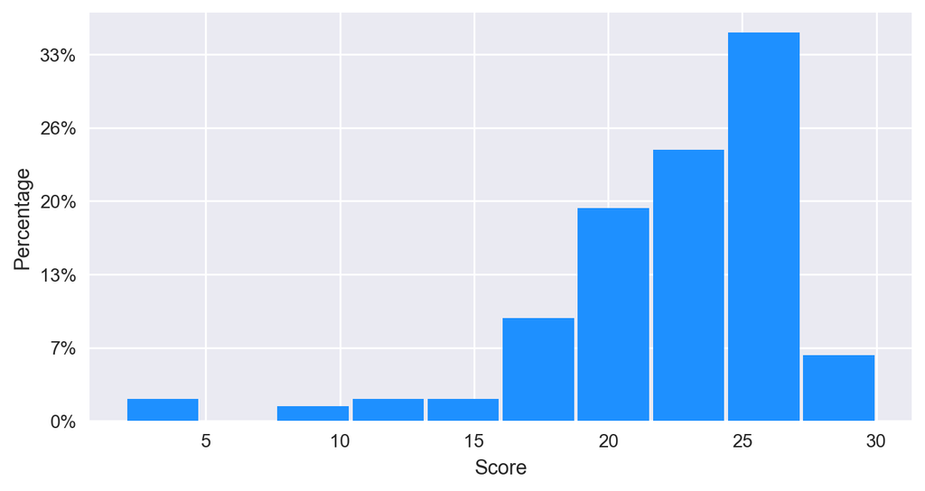

## Assessment Questions

**CODE OF CONDUCT**

- **Use of ChatGPT or similar AI tools is STRICTLY FORBIDDEN in our bi-weekly quizzes.**
- This is a "**limited open-computer**" assessment.
- **You must work on this assessment on your own and you must neither provide nor receive any help from anyone.**
- **You must not share this questions notebook nor your solutions with anyone, neither before submission nor after.**
- Please see Canvas for the full `Code of Conduct`.

**INSTRUCTIONS**

1. You **must not** delete any existing cells in this notebook and you **must not** modify any existing cell tags. If you accidentally delete a cell, you will need to go to the "Edit" menu option and select "Undo Delete Cells".
2. In an answer cell, any direct action **required from you** will be indicated by UPPER CASE PYTHON COMMENTS starting with "###".
3. In general, the value of "999" will denote a dummy placeholder.
4. You **must not change even a single character** in an existing code cell that is **outside** of the "ADD YOUR CODE BELOW/ ABOVE" block.
5. You **must not** have any additional print() statement outputs of your own for any question in your submission.
6. You **must** run each and every one of your answer cells so that your answers are recorded correctly for marking purposes.
7. Please keep in mind that, if you select "*Restart & Clear Output*" or "*Restart & Run All*" from the "*Kernel*" menu option, your answers for any multiple-choice questions will reset to "**nothing selected**".
8. Please see Canvas for additional assessment instructions.
9. This assessment has 11 questions for a total of 30 points.
10. Good luck!

```python
### PLEASE RUN THIS CELL SO THAT THE DROPDOWN ANSWER SELECTIONS BELOW WORK CORRECTLY
### WARNING!! If you restart your kernel, you will need to run this cell again.
from ipywidgets import interactive
def function_mcq(selection): pass
```

```python
### PLEASE FIRST WRITE YOUR FULL NAME AND STUDENT ID BELOW,
### AND THEN EXECUTE THIS CODE CELL.
# Thank you.
print("""
Name:
Student ID:
""")
```

## Questions 1 Through 5

Consider the confusion matrix below for a binary classification task. You will be computing various performance metrics corresponding to this confusion matrix.

**NOTE:** You may **NOT** use the Scikit-Learn module or any other modules for these questions. You will need to use base Python (that is, simple arithmetic) for your calculations.

| Target | Predicted Negative | Predicted Positive |
| --- | --- | --- |
| Target Negative | 28 | 2 |
| Target Positive | 8 | 32 |

## Question 1 (2 points)

Compute the simple accuracy metric.

```python
### ADD YOUR CODE BELOW


accuracy = 999

### ADD YOUR CODE ABOVE

print(f"accuracy is {accuracy:.2f}")
```

**Go to Top**

## Question 2 (2 points)

Compute the recall metric.

```python
### ADD YOUR CODE BELOW


recall = 999

### ADD YOUR CODE ABOVE

print(f"recall is {recall:.2f}")
```

**Go to Top**

## Question 3 (2 points)

Compute the true negative rate metric.

```python
### ADD YOUR CODE BELOW


tnr = 999

### ADD YOUR CODE ABOVE

print(f"true negative rate is {tnr:.2f}")
```

**Go to Top**

## Question 4 (2 points)

Compute the precision metric.

```python
### ADD YOUR CODE BELOW


precision = 999

### ADD YOUR CODE ABOVE

print(f"precision is {precision:.2f}")
```

**Go to Top**

## Question 5 (2 points)

Compute the (harmonic) average class accuracy metric.

```python
### ADD YOUR CODE BELOW


aca_harmonic = 999

### ADD YOUR CODE ABOVE

print(f"the harmonic average class accuracy is {aca_harmonic:.2f}")
```

**Go to Top**

## Question 6, 7, and 8

Ross tuned two models for a binary classification task, one using KNNs and one using DTs, using the training dataset after a 70%-30% train-test split. For instance, for KNN, it turned out that the best set of hyper-parameter values is `k=10` and `p=1` (the Manhattan distance) with the best 10 features as selected by the Random Forest Importance (RFI) method.

Ross is interested in finding out which method performs better with respect to the AUC metric using the **test dataset**. For this reason, Ross performed 2-repeated 5-fold cross-validation (CV) on the test data using these two models using the AUC metric **in a paired fashion**. That is, he used the same cross-validation methodology **with the same random seed**. He obtained the raw cross-validation results given below as the `auc_knn` and `auc_dt` arrays respectively.

## Question 6 (2 points)

Calculate the mean cross-validated test AUC for each model using the CV results below.

```python
import numpy as np

auc_knn = np.array([0.89, 0.87, 0.87, 0.88, 0.90, 0.89, 0.87, 0.89, 0.88, 0.85])
auc_dt = np.array([0.87, 0.85, 0.85, 0.86, 0.88, 0.87, 0.85, 0.87, 0.86, 0.89])


### ADD YOUR CODE BELOW


auc_knn_mean = 999
auc_dt_mean = 999

### ADD YOUR CODE ABOVE

print(f"average AUC for KNN is {auc_knn_mean:.2f} and average AUC for DT is {auc_dt_mean:.2f}")
```

**Go to Top**

## Question 7 (2 points)

Ross knows that he needs to perform paired t-tests to see if this difference between his KNN and DT models is statistically significant.

Conduct a paired t-test for these two models and report a p-value.

```python
from scipy import stats
import numpy as np

auc_knn = np.array([0.89, 0.87, 0.87, 0.88, 0.90, 0.89, 0.87, 0.89, 0.88, 0.85])
auc_dt = np.array([0.87, 0.85, 0.85, 0.86, 0.88, 0.87, 0.85, 0.87, 0.86, 0.89])


### ADD YOUR CODE BELOW


p_value = 999

### ADD YOUR CODE ABOVE

print(f"the p value is {p_value:.2f}")
```

**Go to Top**

## Question 8 (2 points)

Hypothetically, suppose the p-value you found above is 0.025. Does the difference seem to be significant at a 95% level, and if so, which model is statistically better than the other one based on this particular test dataset?

```python
### PLEASE RUN THIS CELL
q8 = interactive(function_mcq,
                 selection=['nothing selected',
                            'The KNN model is statistically better than the DT model  ',
                            'The DT model is statistically better than the KNN model  ',
                            'Difference is not statistically significant']);
display(q8)
```

```python
### PLEASE RUN THIS CELL AFTER YOUR SELECTION ABOVE
print(f"{q8.kwargs['selection']}")
```

**Go to Top**

## Question 9 (5 points)

You will be working with the `iris.csv` dataset file inside the Canvas Quiz page where you downloaded this Questions notebook. This dataset has no missing values and no outliers.

**NOTE:** This is the famous iris flower dataset that is also used in the Seaborn tutorial on our website.

The goal for this dataset is to predict the value of the target feature `species` for an iris flower given 4 different descriptive features (all measured in centimeters):

1. `sepal length`
2. `sepal width`
3. `petal length`
4. `petal width`

**WARNING:** You **MUST** make sure that your Jupyter notebook and this CSV file are in the same folder. If you are on Google Colab, you need to upload this CSV file under the session storage at the root level. Please see the bottom of [this page](https://rmit.instructure.com/courses/106983/pages/jupyter-notebooks-on-the-cloud-google-colab) for more information.

Please first run the code cell below for practice so that you can see what this dataset looks like.

```python
import pandas as pd

# so that we can see all the columns
pd.set_option('display.max_columns', None)

df = pd.read_csv('iris.csv')

df.sample(n=5, random_state=1)
```

|  | sepal_length_cm | sepal_width_cm | petal_length_cm | petal_width_cm | species |
| --- | --- | --- | --- | --- | --- |
| 14 | 5.8 | 4.0 | 1.2 | 0.2 | setosa |
| 98 | 5.1 | 2.5 | 3.0 | 1.1 | versicolor |
| 75 | 6.6 | 3.0 | 4.4 | 1.4 | versicolor |
| 16 | 5.4 | 3.9 | 1.3 | 0.4 | setosa |
| 131 | 7.9 | 3.8 | 6.4 | 2.0 | virginica |

In this question, you will perform feature selection with the **F-Score** method for prediction of the `species` feature of an iris flower. The number of features to be selected will be determined by a user input.

Specifically, write a program that will do the following:

1. Read in the number of features to be selected, `S`, as a user input.
2. Define the target feature.
3. Define the set of descriptive features.
4. Select the best `S` features using the F-score method. For simplicity, you will use the ENTIRE dataset for selecting the best features (and you will NOT use any train-test split or cross-validation or anything like that).
5. Print the best feature names.

**NOTE:** Some of these tasks above have already been performed for you. So you will just need to fill in the parts where it says `### ADD YOUR CODE`.

```python
import numpy as np
import pandas as pd
from sklearn import feature_selection as fs

df = pd.read_csv("iris.csv")

# task 1: read in the number of features to select as a user input
S = int(float(input('Waiting for input: ')))

# task 2: define the target feature
target = df['species'].values

# task 3: define the set of descriptive features in two different ways:
# 1- as a Pandas data frame (so that we can recover the feature names after feature selection)
# 2- as a Numpy array (to use within scikit-learn functions)
Data_df = df.drop(columns = 'species')
Data_numpy = df.drop(columns = 'species').values


# task 4: select the best S features with the F-score method
# using the entire dataset

### ADD YOUR CODE BELOW


fs_indices_fscore = 999

### ADD YOUR CODE ABOVE


# task 5: let's see what these best features are as selected by the f-score method

### ADD YOUR CODE BELOW

best_features_fscore = [999]

### ADD YOUR CODE ABOVE

# print the best features as a Python list as this looks nicer compared to printing a numpy array
print(list(best_features_fscore))
```

**Go to Top**

## Question 10 (6 points)

In this question, you will predict the `species` target feature of an iris flower using the KNN classifier using a train/ test split approach. The number of neighbours for the KNN classifier will be determined by a user input.

Specifically, write a program that will do the following:

1. Read in the number of neighbours, `K`, for the KNN classifier as a user input.
2. Define the target feature.
3. Define the set of descriptive features.
4. Encode the categorical target feature using label encoding.
5. All descriptive features are numeric, so scale them between 0 and 1
6. Split the dataset as 70% training dataset and 30% test dataset.
7. Fit a KNN classifier with the **Manhattan distance**.
8. Train your classifier with the training dataset.
9. Calculate the prediction accuracy of your model on the test dataset.

**NOTE:** Majority of these tasks above have already been performed for you. So you will just need to fill in the parts where it says `### ADD YOUR CODE`.

```python
import pandas as pd
from sklearn import preprocessing
from sklearn.model_selection import train_test_split
from sklearn.neighbors import KNeighborsClassifier

df = pd.read_csv("iris.csv")

# task 1: read in the number of neighbours, K, for the KNN classifier as a user input
K = int(float(input('Waiting for input: ')))

# task 2: define the target feature
target = df['species'].values

# task 3: define the set of descriptive features
Data = df.drop(columns = 'species').values

# task 4: encode the categorical target feature using label encoding
target_encoded = preprocessing.LabelEncoder().fit_transform(target)

# task 5: all descriptive features are numeric,
# so scale them between 0 and 1
Data_scaled = preprocessing.MinMaxScaler().fit_transform(Data)

# task 6: perform the train/ test split
D_train, D_test, t_train, t_test = train_test_split(Data_scaled,
                                                    target_encoded,
                                                    stratify=target,
                                                    test_size=0.3,
                                                    random_state=1)

### ADD YOUR CODE BELOW

# task 7: fit a KNN classifier with the Manhattan distance

knn_classifier = 999

# task 8: train your classifier with the training dataset
   ### ADD YOUR ONE-LINE CODE HERE TO TRAIN YOUR MODEL

# task 9: calculate the prediction accuracy of your model on the test dataset.

test_accuracy = 999

### ADD YOUR CODE ABOVE

print(f'Accuracy of the KNN classifier with K={K} on the test dataset is {test_accuracy:.2f}.')
```

**Go to Top**

## Question 11: Challenge Question (3 points)

**This is a Challenge Question, please only attempt this AFTER attempting the rest of the questions!**

**Also be aware of how much time you have left!**

In this question, similar to the feature selection question above, you will perform feature selection to find the **best two features**, but this time, with the **spFSR** method for prediction of the `species` feature of an iris flower. The tutorial [here](https://www.featureranking.com/tutorials/machine-learning-tutorials/sk-part-2-feature-selection-and-ranking/) on our website might be useful.

You will use 1-KNN as the wrapper with the **Euclidean** distance and the "AUC" metric as the performance criterion.

Here is the [link](https://github.com/akmand/spFSR/blob/master/spFSR.py) to the spFSR Python code. You will need to copy this code in the **same folder** as your Jupyter notebook.

For simplicity, you will report the sum of the feature importances of these best two features.

```python
import numpy as np
import pandas as pd
from sklearn.neighbors import KNeighborsClassifier


# pay attention to capitalization below!
from spFSR import SpFSR

df = pd.read_csv("iris.csv")

target = df['species'].values
Data_numpy = df.drop(columns = 'species').values

np.random.seed(999)

num_features = 2


### ADD YOUR CODE BELOW


feat_imp_sum = 999

### ADD YOUR CODE ABOVE
```

```python
### YOU MUST RUN THIS CELL AT THE END TO PRINT THE SUM FOR MARKING
print(f"Sum of the feature importances of the best two features is {feat_imp_sum:.2f}")
```

**Go to Top**

Marking & Feedback by **[SageGrader.com](https://sagegrader.com)**: The Sage Way To Grade.